# Exloratory and Inferential Analysis - Experiment 4

Juan Carpio

## Setting directory and relevant library

```r
# Reading Clean File and setting relevant libraries.

## Change working directory
setwd("C:/Users/K56CA/Dropbox/PhD/Experiments Incentives/Follow_Up_Incentives/incentives-repo")

##Relevant libraries
library("Hmisc")
library("plyr")
library("dplyr")
library("tidyr")
library("ggplot2")
library("reshape2")
library("leaps")
library("car")
library("ordinal", lib.loc="~/R/win-library/3.2")
```

## Preparing data frame for analysis

```r
## read raw_data
data_clean_imp<-read.csv("clean_data_Exp4.csv")
## correcting ID veriable
data_clean<- mutate(data_clean_imp, ID= X+1) %>%
        select(ID, everything(), -X)

##Define factor variables

data_clean$r_amount <- factor(data_clean$r_amount, levels = c(1,2),
                      labels = c("£2", "£5"))

data_clean$r_type <- factor(data_clean$r_type, levels = c(1,2),
                    labels = c("Cash", "Product"))

data_clean$gender <- factor(data_clean$gender, levels = c(1,2),
                    labels = c("Male", "Female"))

data_clean$income <- factor(data_clean$income, levels = c(1:5),
                    labels = c("< 15k", "15k-19k",
                               "20k-29k", "> 30k", "No.Ans"))

data_clean$employ <- factor(data_clean$employ, levels = c(1:6),
                    labels = c("FT-Emp", "PT-Emp","Unempl.",
                               "Stud.", "Retired","Other"))


## Adding totals for Measures: Neg.Evaluations and Expectations

expect_1<-c("exp_x1_K","exp_x1_T", "exp_x1_S.R","exp_x1_G")
expect_2<-c("exp_x2_K","exp_x2_T", "exp_x2_S.R","exp_x2_G")
expect_all<-c("exp_x1_K","exp_x1_T", "exp_x1_S.R","exp_x1_G",
              "exp_x2_K","exp_x2_T", "exp_x2_S.R","exp_x2_G")
neg_eval<-c("neg.ev_1","neg.ev_2.R","neg.ev_3","neg.ev_4.R",
            "neg.ev_5","neg.ev_6","neg.ev_7.R","neg.ev_8",
            "neg.ev_9","neg.ev_10.R", "neg.ev_11","neg.ev_12")

final_df<-data_clean %>% mutate(
        tot_exp1 = rowMeans(.[expect_1]),
        tot_exp2 = rowMeans(.[expect_2]),
        exp_all = rowMeans(.[expect_all]),
        tot_neg_eval = rowMeans(.[neg_eval])
        )

#final_df %>% group_by(r_amount) %>% summarise(avg = mean(age))

# Code to audit cases ###################
# final_df %>% filter(ID==315) %>% gather()
#########################################
```

## Chi Square Preferences First Choice (page 140)

More than 80% prefered not to share the rward with anyone as a first choice. Such difference was highly significant.

```r
long_data<-melt(final_df, measure.var= c("vd_0f","vd_1f","vd_2f"),
        id.var = c("ID","r_type", "r_amount", "tot_neg_eval",
                   "tot_exp1","tot_exp2", "exp_all"))

chi_data<- filter(long_data, value==1)

#Summarise first choice frequencies and proportions
fr<-as.matrix(table(chi_data$variable))
p <- c(fr[1,1]/nrow(chi_data), fr[2,1]/nrow(chi_data),
                fr[3,1]/nrow(chi_data))

#calculating chi square
fr
```

```
##       [,1]
## vd_0f  338
## vd_1f   30
## vd_2f   33
```

```r
p
```

```
##      vd_0f      vd_1f      vd_2f
## 0.84289277 0.07481297 0.08229426
```

```r
chisq.test(fr)
```

```
##
##  Chi-squared test for given probabilities
##
## data:  fr
## X-squared = 468.57, df = 2, p-value < 2.2e-16
```

# Scheme Ranking and Reward Amount (Section 3.3.2)

## Reward Amount and Expectations Sharing with 1 FRIEND

### Mann Witney Test

```r
low.exp_df<-final_df %>% filter(tot_exp1 <= 4.5) %>%
        select(vd_0f, vd_1f, vd_2f, r_amount)

high.exp_df<-final_df %>% filter(tot_exp1 > 4.5) %>%
        select(vd_0f, vd_1f, vd_2f, r_amount)


u.low<-lapply(low.exp_df[,c(1:3)],
          function(x) wilcox.test(x ~low.exp_df[,4],var.equal= TRUE))
u.low
```

```
## $vd_0f
##
##  Wilcoxon rank sum test with continuity correction
##
## data:  x by low.exp_df[, 4]
## W = 15, p-value = 0.02085
## alternative hypothesis: true location shift is not equal to 0
##
##
## $vd_1f
##
##  Wilcoxon rank sum test with continuity correction
##
## data:  x by low.exp_df[, 4]
## W = 52, p-value = 0.01018
## alternative hypothesis: true location shift is not equal to 0
##
##
## $vd_2f
##
##  Wilcoxon rank sum test with continuity correction
##
## data:  x by low.exp_df[, 4]
## W = 25, p-value = 0.5839
## alternative hypothesis: true location shift is not equal to 0
```

```r
u.high<-lapply(high.exp_df[,c(1:3)],
          function(x) wilcox.test(x ~high.exp_df[,4],var.equal= TRUE))
u.high
```

```
## $vd_0f
##
##  Wilcoxon rank sum test with continuity correction
##
## data:  x by high.exp_df[, 4]
## W = 19332, p-value = 0.2413
## alternative hypothesis: true location shift is not equal to 0
##
##
## $vd_1f
##
##  Wilcoxon rank sum test with continuity correction
##
## data:  x by high.exp_df[, 4]
## W = 18084, p-value = 0.6519
## alternative hypothesis: true location shift is not equal to 0
##
##
## $vd_2f
##
##  Wilcoxon rank sum test with continuity correction
##
## data:  x by high.exp_df[, 4]
## W = 17440, p-value = 0.2685
## alternative hypothesis: true location shift is not equal to 0
```

### FIGURE 16: Ranking, Reward Amount and Expectations Sharing with 1 FRIEND

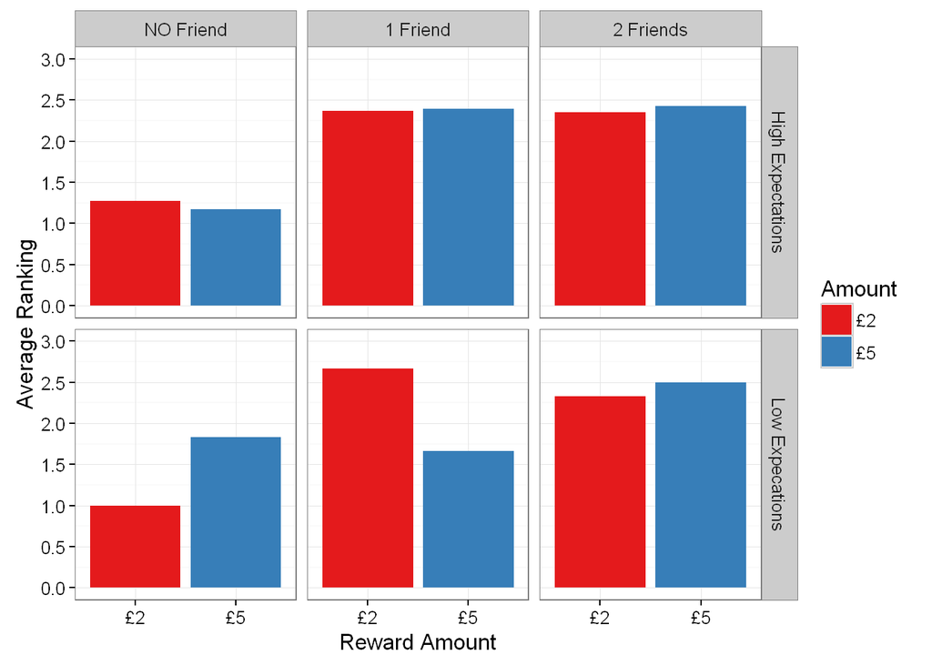

```r
data<-melt(final_df, measure.var= c("vd_0f","vd_1f", "vd_2f"),
         id.var = c("r_type", "r_amount", "exp_all"))

dd<-data %>%  mutate(catg = ifelse(exp_all < 4.5, "Negative Expectations","Positive Expectations"))


pct <- data %>%
  group_by(variable,r_amount,value) %>%
  summarise(n=n()) %>%
  group_by(variable) %>%
  mutate(perc=100*n/sum(n))

pct$variable <- factor(pct$variable,
                labels = c("NO Friend", "1 Friend", "2 Friends"))

names(pct)[2]<-"Reward"

## BY EXPECTATION CATEGORY SEPARATING EXPECTATIONS
data<-melt(final_df, measure.var= c("vd_0f","vd_1f", "vd_2f"),
         id.var = c("r_type", "r_amount", "tot_exp1", "tot_exp2"))

exp_df<-data %>% mutate(cat.exp1 = ifelse(tot_exp1 < 4.5,
                "Low Expecations","High Expectations"),
                        cat.exp2 = ifelse(tot_exp2 < 4.5,
                "Low Expectations","High Expectations"))
exp_df$variable <- factor(exp_df$variable,
                labels = c("NO Friend", "1 Friend", "2 Friends"))

# Expectations sharing with one friend
avg_rank1<-exp_df %>% group_by(variable,r_amount, cat.exp1) %>%
        summarise(rank=mean(value))
names(avg_rank1)[2]<-c("Amount")

ggplot(avg_rank1, aes(x=Amount, y=rank, fill=Amount) )+
        geom_bar(stat="identity",position="dodge")+
        facet_grid( cat.exp1~ variable )+
        scale_fill_brewer(palette="Set1")+
        scale_y_continuous(limits =c(0,3), breaks=seq(0,3, 0.5))+
        theme_bw()+
        labs(x="Reward Amount", y="Average Ranking")
```

## Reward Amount and Expectations Sharing with 2 FRIENDS

### Mann Witney Test

```r
low.exp_df<-final_df %>% filter(tot_exp2 <= 4.5) %>%
        select(vd_0f, vd_1f, vd_2f, r_amount)

high.exp_df<-final_df %>% filter(tot_exp2 > 4.5) %>%
        select(vd_0f, vd_1f, vd_2f, r_amount)


u.low.2f<-lapply(low.exp_df[,c(1:3)],
          function(x) wilcox.test(x ~low.exp_df[,4],var.equal= TRUE))
u.low.2f
```

```
## $vd_0f
##
##  Wilcoxon rank sum test with continuity correction
##
## data:  x by low.exp_df[, 4]
## W = 42.5, p-value = 0.02873
## alternative hypothesis: true location shift is not equal to 0
##
##
## $vd_1f
##
##  Wilcoxon rank sum test with continuity correction
##
## data:  x by low.exp_df[, 4]
## W = 63.5, p-value = 0.8
## alternative hypothesis: true location shift is not equal to 0
##
##
## $vd_2f
##
##  Wilcoxon rank sum test with continuity correction
##
## data:  x by low.exp_df[, 4]
## W = 81, p-value = 0.131
## alternative hypothesis: true location shift is not equal to 0
```

```r
u.high.2f<-lapply(high.exp_df[,c(1:3)],
          function(x) wilcox.test(x ~high.exp_df[,4],var.equal= TRUE))
u.high.2f
```

```
## $vd_0f
##
##  Wilcoxon rank sum test with continuity correction
##
## data:  x by high.exp_df[, 4]
## W = 18554, p-value = 0.2357
## alternative hypothesis: true location shift is not equal to 0
##
##
## $vd_1f
##
##  Wilcoxon rank sum test with continuity correction
##
## data:  x by high.exp_df[, 4]
## W = 17758, p-value = 0.9945
## alternative hypothesis: true location shift is not equal to 0
##
##
## $vd_2f
##
##  Wilcoxon rank sum test with continuity correction
##
## data:  x by high.exp_df[, 4]
## W = 16220, p-value = 0.107
## alternative hypothesis: true location shift is not equal to 0
```

### FIGURE 17: Ranking, Reward Amount and Expectations Sharing with 2 FRIENDS

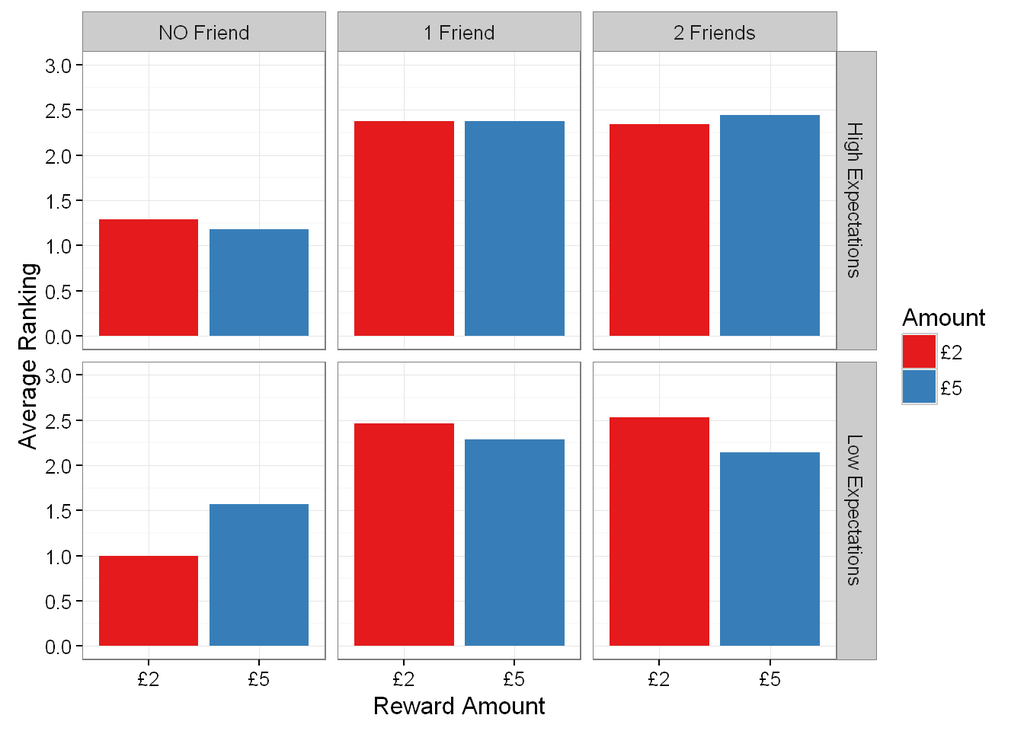

```r
data<-melt(final_df, measure.var= c("vd_0f","vd_1f", "vd_2f"),
         id.var = c("r_type", "r_amount", "exp_all"))

dd<-data %>%  mutate(catg = ifelse(exp_all < 4.5, "Negative Expectations","Positive Expectations"))


pct <- data %>%
  group_by(variable,r_amount,value) %>%
  summarise(n=n()) %>%
  group_by(variable) %>%
  mutate(perc=100*n/sum(n))

pct$variable <- factor(pct$variable,
                labels = c("NO Friend", "1 Friend", "2 Friends"))

names(pct)[2]<-"Reward"

## BY EXPECTATION CATEGORY SEPARATING EXPECTATIONS
data<-melt(final_df, measure.var= c("vd_0f","vd_1f", "vd_2f"),
         id.var = c("r_type", "r_amount", "tot_exp1", "tot_exp2"))

exp_df<-data %>% mutate(cat.exp1 = ifelse(tot_exp1 < 4.5,
                "Low Expecations","High Expectations"),
                        cat.exp2 = ifelse(tot_exp2 < 4.5,
                "Low Expectations","High Expectations"))
exp_df$variable <- factor(exp_df$variable,
                labels = c("NO Friend", "1 Friend", "2 Friends"))

# Expectations sharing with two friends
avg_rank2<-exp_df %>% group_by(variable,r_amount, cat.exp2) %>%
        summarise(rank=mean(value))
names(avg_rank2)[2]<-c("Amount")

ggplot(avg_rank2, aes(x=Amount, y=rank, fill=Amount) )+
        geom_bar(stat="identity",position="dodge")+
        facet_grid( cat.exp2~ variable )+
        scale_fill_brewer(palette="Set1")+
        scale_y_continuous(limits =c(0,3), breaks=seq(0,3, 0.5))+
        theme_bw()+
        labs(x="Reward Amount", y="Average Ranking")
```

# Reward Amount and expectations about friends’ reactions (Section 3.3.3)

### Mann Whitney test

```r
#Median
final_df %>% select(tot_exp1, tot_exp2, r_amount) %>%
                group_by(r_amount) %>%
                summarise(median(tot_exp1),median(tot_exp2),
                          mean(tot_exp1),mean(tot_exp2))
```

```
## Source: local data frame [2 x 5]
##
##   r_amount median(tot_exp1) median(tot_exp2) mean(tot_exp1) mean(tot_exp2)
## 1       £2                7             6.75       7.032500       6.688750
## 2       £5                8             7.25       7.671642       7.231343
```

```r
# Mann Whitney U-Test
u<-lapply(final_df[,c(31:33)],
          function(x) wilcox.test(x ~ final_df[,29], var.equal= FALSE))
u
```

```
## $tot_exp1
##
##  Wilcoxon rank sum test with continuity correction
##
## data:  x by final_df[, 29]
## W = 15590, p-value = 7.323e-05
## alternative hypothesis: true location shift is not equal to 0
##
##
## $tot_exp2
##
##  Wilcoxon rank sum test with continuity correction
##
## data:  x by final_df[, 29]
## W = 16456, p-value = 0.00153
## alternative hypothesis: true location shift is not equal to 0
##
##
## $exp_all
##
##  Wilcoxon rank sum test with continuity correction
##
## data:  x by final_df[, 29]
## W = 15933, p-value = 0.000299
## alternative hypothesis: true location shift is not equal to 0
```

### FIGURE 18: Plot Reward Amount and Expectations Friends Reactions

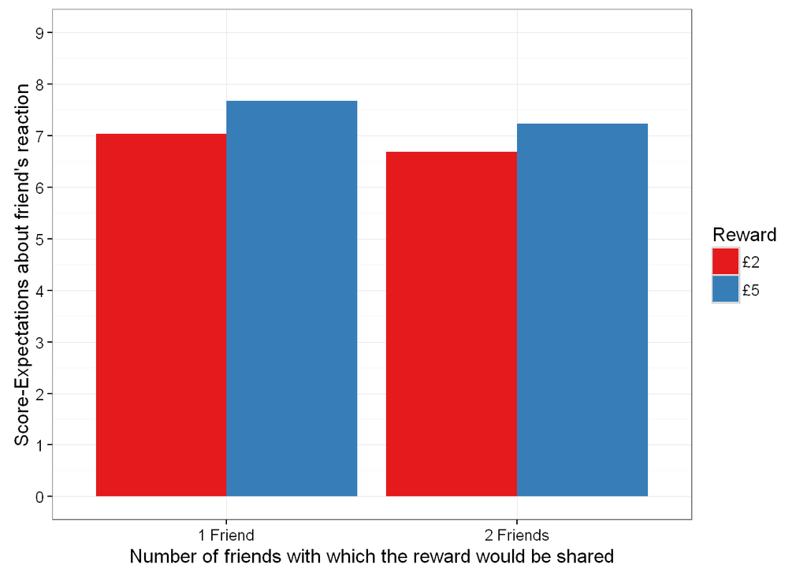

```r
gdata<-melt(final_df, measure.var= c("tot_exp1", "tot_exp2" ),
         id.var = c("r_type", "r_amount"))

gdata$variable <- factor(gdata$variable,
                labels = c("1 Friend",
                          "2 Friends"))
names(gdata)[2]<-"Reward"


ggplot(gdata, aes(x=variable, y=value, fill=Reward))+
        geom_bar(stat = "summary", fun.y = "mean",position="dodge")+
        scale_y_continuous(limits =c(0,9), breaks=seq(0,9,1))+
        scale_fill_brewer(palette="Set1")+
        labs(x="Number of friends with which the reward would be shared",
                y="Score-Expectations about friend's reaction")+
        theme_bw()
```

# Scheme Ranking and Reward Framing (Section 3.3.4)

Significant differences were found in terms of the type of reward (Cash or product) among the participants who preferred to share their reward (minority).

### Means and Mann Whitney Test

```r
#Means
final_df %>% select(vd_0f, vd_1f, vd_2f, r_type) %>%
                group_by(r_type) %>%
                summarise(mean(vd_0f),mean(vd_1f),mean(vd_2f))
```

```
## Source: local data frame [2 x 4]
##
##    r_type mean(vd_0f) mean(vd_1f) mean(vd_2f)
## 1    Cash    1.263959    2.060914    2.675127
## 2 Product    1.196078    2.681373    2.122549
```

```r
# Mann Whitney U-Test
u<-lapply(final_df[,c(2:4)],
          function(x) wilcox.test(x ~ final_df[,30], var.equal= FALSE))

u
```

```
## $vd_0f
##
##  Wilcoxon rank sum test with continuity correction
##
## data:  x by final_df[, 30]
## W = 20934, p-value = 0.2527
## alternative hypothesis: true location shift is not equal to 0
##
##
## $vd_1f
##
##  Wilcoxon rank sum test with continuity correction
##
## data:  x by final_df[, 30]
## W = 9107.5, p-value < 2.2e-16
## alternative hypothesis: true location shift is not equal to 0
##
##
## $vd_2f
##
##  Wilcoxon rank sum test with continuity correction
##
## data:  x by final_df[, 30]
## W = 30030, p-value < 2.2e-16
## alternative hypothesis: true location shift is not equal to 0
```

### FIGURE 19: Average ranking of each incentive scheme comparing the “Reward Framing”.

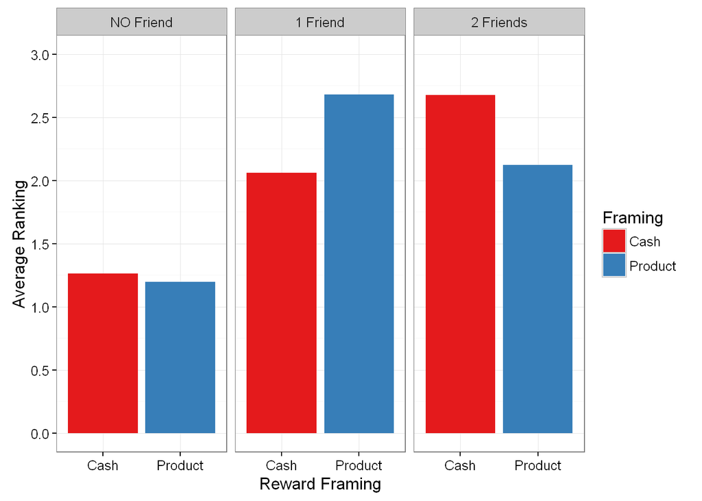

```r
data<-melt(final_df, measure.var= c("vd_0f","vd_1f", "vd_2f"),
         id.var = c("r_type", "r_amount", "tot_exp1", "tot_exp2"))

avg_rank<-data %>% group_by(variable,r_type) %>%
        summarise(rank=mean(value))

avg_rank$variable <- factor(avg_rank$variable,
                labels = c("NO Friend", "1 Friend", "2 Friends"))
names(avg_rank)[2]<-c("Framing")

ggplot(avg_rank, aes(x=Framing, y=rank, fill=Framing) )+
        geom_bar(stat="identity",position="dodge")+
        facet_grid(~ variable)+
        scale_fill_brewer(palette="Set1")+
        scale_y_continuous(limits =c(0,3), breaks=seq(0,3, 0.5))+
        theme_bw()+
        labs(x="Reward Framing", y="Average Ranking")
```

## Reward Framing and Expectations Sharing with 1 FRIEND

### Mann Whitney Test

```
## $vd_0f
##
##  Wilcoxon rank sum test with continuity correction
##
## data:  x by low.exp_df[, 4]
## W = 42, p-value = 0.1199
## alternative hypothesis: true location shift is not equal to 0
##
##
## $vd_1f
##
##  Wilcoxon rank sum test with continuity correction
##
## data:  x by low.exp_df[, 4]
## W = 3.5, p-value = 0.001338
## alternative hypothesis: true location shift is not equal to 0
##
##
## $vd_2f
##
##  Wilcoxon rank sum test with continuity correction
##
## data:  x by low.exp_df[, 4]
## W = 48.5, p-value = 0.05001
## alternative hypothesis: true location shift is not equal to 0
```

```
## $vd_0f
##
##  Wilcoxon rank sum test with continuity correction
##
## data:  x by high.exp_df[, 4]
## W = 19056, p-value = 0.4347
## alternative hypothesis: true location shift is not equal to 0
##
##
## $vd_1f
##
##  Wilcoxon rank sum test with continuity correction
##
## data:  x by high.exp_df[, 4]
## W = 8669, p-value < 2.2e-16
## alternative hypothesis: true location shift is not equal to 0
##
##
## $vd_2f
##
##  Wilcoxon rank sum test with continuity correction
##
## data:  x by high.exp_df[, 4]
## W = 27646, p-value < 2.2e-16
## alternative hypothesis: true location shift is not equal to 0
```

### FIGURE 20: Average ranking comparing the “Reward Framing”, based on the expectations about sharing the reward with ONE friend.

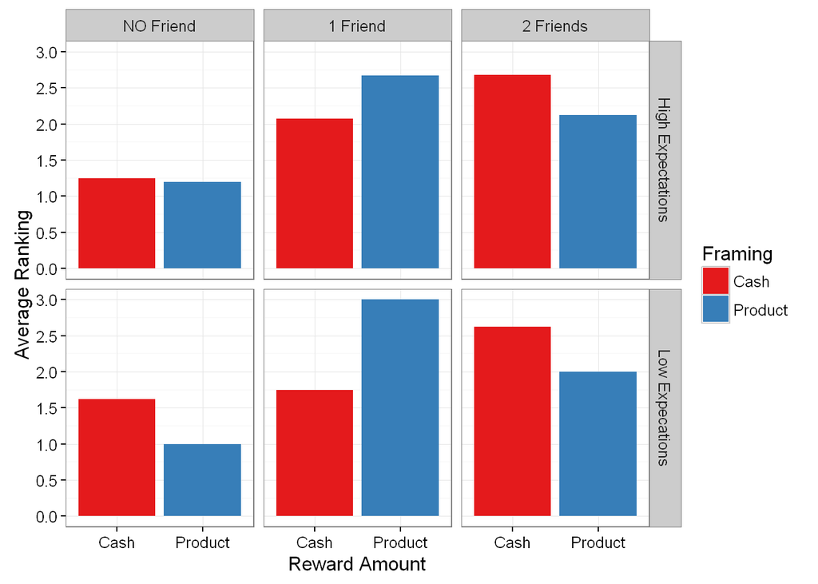

```r
exp_df<-data %>% mutate(cat.exp1 = ifelse(tot_exp1 < 4.5,
                "Low Expecations","High Expectations"),
                        cat.exp2 = ifelse(tot_exp2 < 4.5,
                "Low Expectations","High Expectations"))
exp_df$variable <- factor(exp_df$variable,
                labels = c("NO Friend", "1 Friend", "2 Friends"))

# Expectations sharing with one friend (FIGURE 20)
avg_rank1<-exp_df %>% group_by(variable,r_type, cat.exp1) %>%
        summarise(rank=mean(value))
names(avg_rank1)[2]<-c("Framing")

ggplot(avg_rank1, aes(x=Framing, y=rank, fill=Framing) )+
        geom_bar(stat="identity",position="dodge")+
        facet_grid( cat.exp1~ variable )+
        scale_fill_brewer(palette="Set1")+
        scale_y_continuous(limits =c(0,3), breaks=seq(0,3, 0.5))+
        theme_bw()+
        labs(x="Reward Amount", y="Average Ranking")
```

## Reward Framing and Expectations Sharing with 2 FRIENDS

### Mann Whitney Test

```
## $vd_0f
##
##  Wilcoxon rank sum test with continuity correction
##
## data:  x by low.exp_df[, 4]
## W = 84, p-value = 0.1658
## alternative hypothesis: true location shift is not equal to 0
##
##
## $vd_1f
##
##  Wilcoxon rank sum test with continuity correction
##
## data:  x by low.exp_df[, 4]
## W = 11, p-value = 6.874e-05
## alternative hypothesis: true location shift is not equal to 0
##
##
## $vd_2f
##
##  Wilcoxon rank sum test with continuity correction
##
## data:  x by low.exp_df[, 4]
## W = 115, p-value = 0.005464
## alternative hypothesis: true location shift is not equal to 0
```

```
## $vd_0f
##
##  Wilcoxon rank sum test with continuity correction
##
## data:  x by high.exp_df[, 4]
## W = 18350, p-value = 0.3841
## alternative hypothesis: true location shift is not equal to 0
##
##
## $vd_1f
##
##  Wilcoxon rank sum test with continuity correction
##
## data:  x by high.exp_df[, 4]
## W = 8378, p-value < 2.2e-16
## alternative hypothesis: true location shift is not equal to 0
##
##
## $vd_2f
##
##  Wilcoxon rank sum test with continuity correction
##
## data:  x by high.exp_df[, 4]
## W = 26434, p-value < 2.2e-16
## alternative hypothesis: true location shift is not equal to 0
```

### FIGURE 21: Average ranking comparing the “Reward Framing”, based on the expectations about sharing the reward with TWO friends.

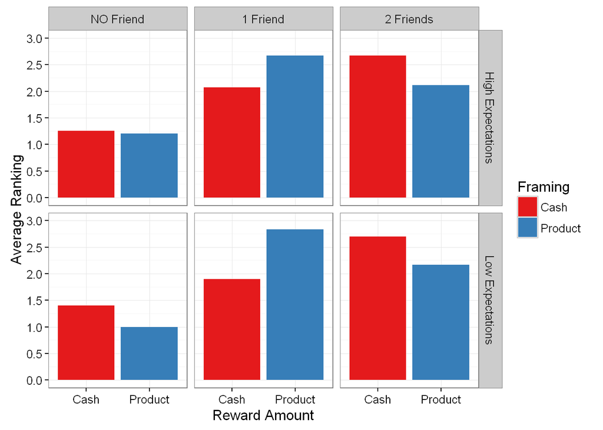

```r
exp_df<-data %>% mutate(cat.exp1 = ifelse(tot_exp1 < 4.5,
                "Low Expecations","High Expectations"),
                        cat.exp2 = ifelse(tot_exp2 < 4.5,
                "Low Expectations","High Expectations"))
exp_df$variable <- factor(exp_df$variable,
                labels = c("NO Friend", "1 Friend", "2 Friends"))

# Expectations sharing with two friends (FIGURE 21)
avg_rank2<-exp_df %>% group_by(variable,r_type, cat.exp2) %>%
        summarise(rank=mean(value))
names(avg_rank2)[2]<-c("Framing")

ggplot(avg_rank2, aes(x=Framing, y=rank, fill=Framing) )+
        geom_bar(stat="identity",position="dodge")+
        facet_grid( cat.exp2~ variable )+
        scale_fill_brewer(palette="Set1")+
        scale_y_continuous(limits =c(0,3), breaks=seq(0,3, 0.5))+
        theme_bw()+
        labs(x="Reward Amount", y="Average Ranking")
```

# Reward Framing and expectations about friends’ (Section 3.3.5)

### Mann Whitney Test and Median

```
## Source: local data frame [2 x 5]
##
##    r_type median(tot_exp1) median(tot_exp2) mean(tot_exp1) mean(tot_exp2)
## 1    Cash             7.50                7       7.266497       6.860406
## 2 Product             7.75                7       7.436275       7.057598
```

```
##               p.value
## tot_exp1 2.463798e-01
## tot_exp2 1.295312e-01
## exp_all  1.984434e-01
```

### FIGURE 22: Differences between “Reward Framing” in terms of expectations about sharing the reward with either one or two friends.

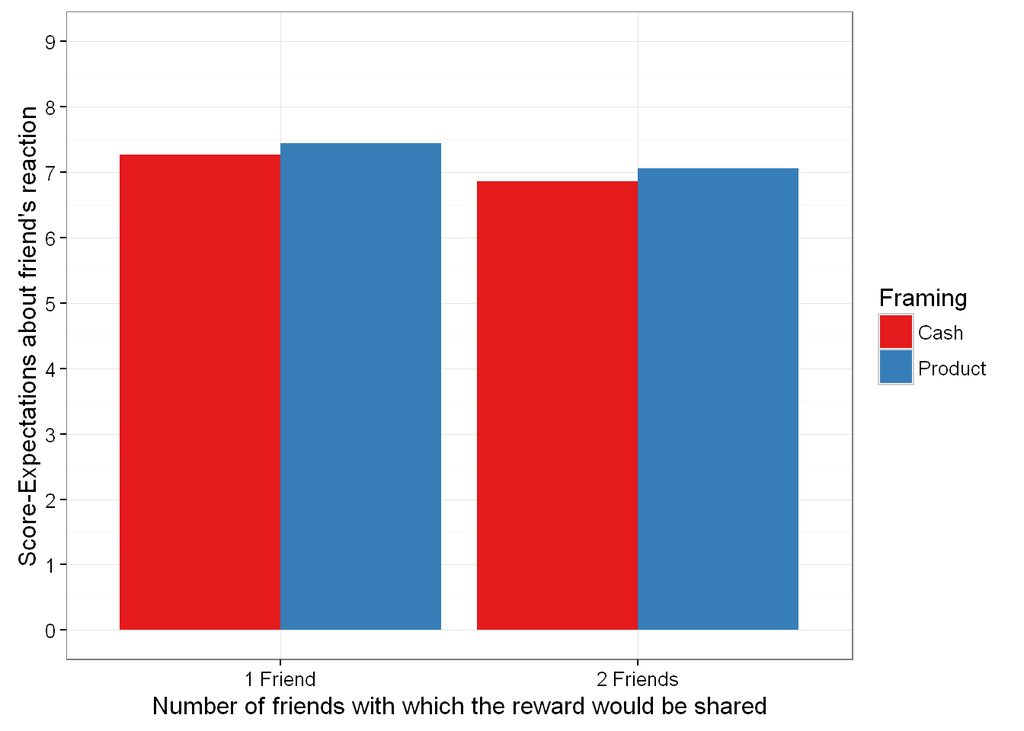

```r
gdata<-melt(final_df, measure.var= c("tot_exp1", "tot_exp2" ),
         id.var = c("r_type", "r_amount"))

gdata$variable <- factor(gdata$variable,
                labels = c("1 Friend",
                          "2 Friends"))
names(gdata)[1]<-"Framing"


ggplot(gdata, aes(x=variable, y=value, fill=Framing))+
        geom_bar(stat = "summary", fun.y = "mean",position="dodge")+
        scale_y_continuous(limits =c(0,9), breaks=seq(0,9,1))+
        scale_fill_brewer(palette="Set1")+
        labs(x="Number of friends with which the reward would be shared",
                y="Score-Expectations about friend's reaction")+
        theme_bw()
```

# Interaction between Reward Framing and Reward Amount (Section 3.3.6)

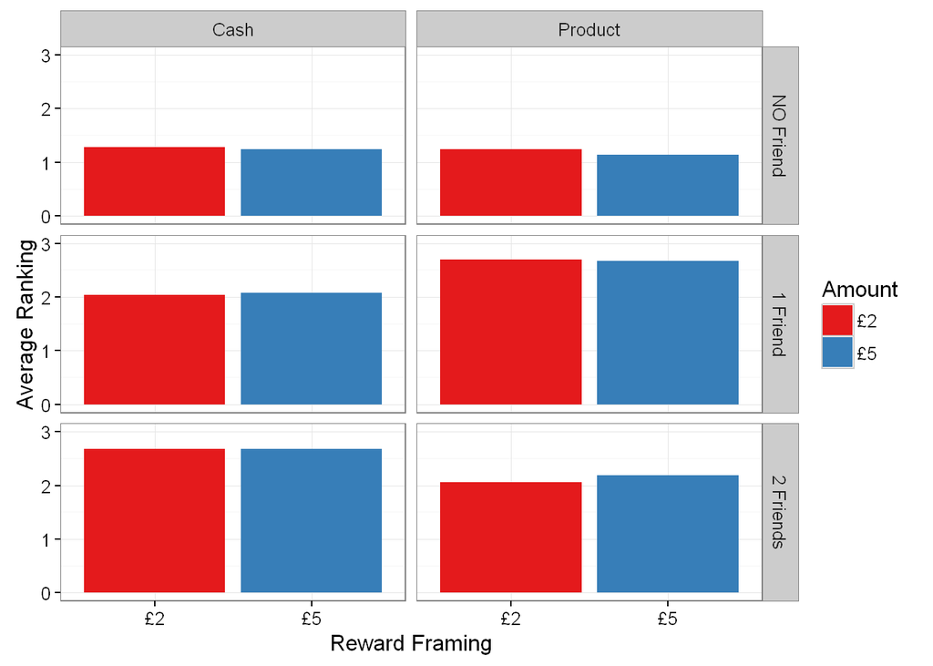

# Fears of negatives evaluations, AGE and GENDER (Section 3.3.7)

```
##
##  Welch Two Sample t-test
##
## data:  final_df[, 34] by final_df[, 29]
## t = 0.24081, df = 398.47, p-value = 0.8098
## alternative hypothesis: true difference in means is not equal to 0
## 95 percent confidence interval:
##  -0.1395334  0.1784886
## sample estimates:
## mean in group £2 mean in group £5
##         3.331667         3.312189
```

```
##
##  Welch Two Sample t-test
##
## data:  final_df[, 34] by final_df[, 30]
## t = -0.14368, df = 398.17, p-value = 0.8858
## alternative hypothesis: true difference in means is not equal to 0
## 95 percent confidence interval:
##  -0.1706843  0.1474352
## sample estimates:
##    mean in group Cash mean in group Product
##              3.315990              3.327614
```

```
##
##  Welch Two Sample t-test
##
## data:  final_df[, 34] by final_df[, 25]
## t = 5.5858, df = 398.75, p-value = 4.313e-08
## alternative hypothesis: true difference in means is not equal to 0
## 95 percent confidence interval:
##  0.2785258 0.5810562
## sample estimates:
##   mean in group Male mean in group Female
##             3.555556             3.125765
```

```
##      x    y
## x 1.00 0.29
## y 0.29 1.00
##
## n= 401
##
##
## P
##   x  y
## x     0
## y  0
```

### FIGURE 24: Relationship between age and the Fears of Negative Evaluations scale,

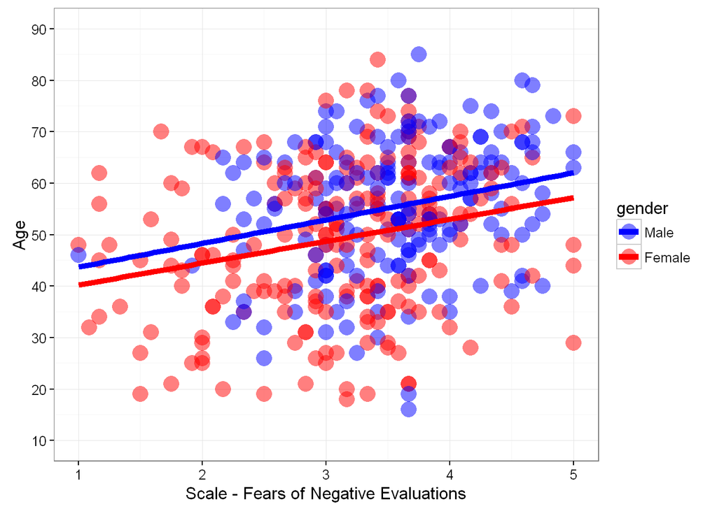

### Mediations Analysis FNE and Expectations about friends’ reactions

```r
long_data<-melt(final_df, measure.var= c("vd_0f","vd_1f","vd_2f"),
        id.var = c("ID","r_type", "r_amount", "tot_neg_eval",
                   "tot_exp1","tot_exp2", "exp_all", "gender",
                   "income", "age", "employ"))

mr_data<- filter(long_data, value==1)
mr_data[[3]]=as.factor(mr_data[[3]])

mediation1<-lm(tot_neg_eval~tot_exp1, data = mr_data)
mediation2<-lm(tot_neg_eval~tot_exp2, data = mr_data)
summary (mediation1)
```

```
##
## Call:
## lm(formula = tot_neg_eval ~ tot_exp1, data = mr_data)
##
## Residuals:
##      Min       1Q   Median       3Q      Max
## -2.34818 -0.42593  0.09082  0.50470  1.69649
##
## Coefficients:
##             Estimate Std. Error t value Pr(>|t|)
## (Intercept)  3.40401    0.18299   18.60   <2e-16 ***
## tot_exp1    -0.01117    0.02427   -0.46    0.646
## ---
## Signif. codes:  0 '***' 0.001 '**' 0.01 '*' 0.05 '.' 0.1 ' ' 1
##
## Residual standard error: 0.8096 on 399 degrees of freedom
## Multiple R-squared:  0.0005302,  Adjusted R-squared:  -0.001975
## F-statistic: 0.2116 on 1 and 399 DF,  p-value: 0.6457
```

```r
summary (mediation2)
```

```
##
## Call:
## lm(formula = tot_neg_eval ~ tot_exp2, data = mr_data)
##
## Residuals:
##      Min       1Q   Median       3Q      Max
## -2.34632 -0.39972  0.08232  0.52293  1.74948
##
## Coefficients:
##             Estimate Std. Error t value Pr(>|t|)
## (Intercept)  3.23855    0.17086  18.954   <2e-16 ***
## tot_exp2     0.01198    0.02385   0.502    0.616
## ---
## Signif. codes:  0 '***' 0.001 '**' 0.01 '*' 0.05 '.' 0.1 ' ' 1
##
## Residual standard error: 0.8096 on 399 degrees of freedom
## Multiple R-squared:  0.0006315,  Adjusted R-squared:  -0.001873
## F-statistic: 0.2521 on 1 and 399 DF,  p-value: 0.6159
```

# Expectations about Friends’ Reaction in general (Section 3.3.8)

### Mann Whitney Test and Means

```r
gdata<-melt(final_df, measure.var= c("tot_exp1", "tot_exp2"),
         id.var = c("gender"))

#Median and Mean per number of friends
gdata %>% group_by(variable) %>%
        summarise(median(value),mean(value))
```

```
## Source: local data frame [2 x 3]
##
##   variable median(value) mean(value)
## 1 tot_exp1          7.75    7.352868
## 2 tot_exp2          7.00    6.960723
```

```r
#Median and Mean per Gender
gdata %>% group_by(gender) %>%
        summarise(median(value),mean(value))
```

```
## Source: local data frame [2 x 3]
##
##   gender median(value) mean(value)
## 1   Male          7.00    6.825820
## 2 Female          7.75    7.434633
```

```r
# Mann Whitney between number of friends
wilcox.test(gdata[,3] ~ gdata[,2], var.equal= FALSE)
```

```
##
##  Wilcoxon rank sum test with continuity correction
##
## data:  gdata[, 3] by gdata[, 2]
## W = 91860, p-value = 0.0003977
## alternative hypothesis: true location shift is not equal to 0
```

```r
# Mann Whitney between GENDER

lapply(final_df[,c(31:32)],
          function(x) wilcox.test(x ~ final_df[,25], var.equal= FALSE))
```

```
## $tot_exp1
##
##  Wilcoxon rank sum test with continuity correction
##
## data:  x by final_df[, 25]
## W = 15662, p-value = 0.0001552
## alternative hypothesis: true location shift is not equal to 0
##
##
## $tot_exp2
##
##  Wilcoxon rank sum test with continuity correction
##
## data:  x by final_df[, 25]
## W = 16220, p-value = 0.001144
## alternative hypothesis: true location shift is not equal to 0
```

### FIGURE 25: Differences between “Genders” in terms of expectations about sharing the reward with either one or two friends.

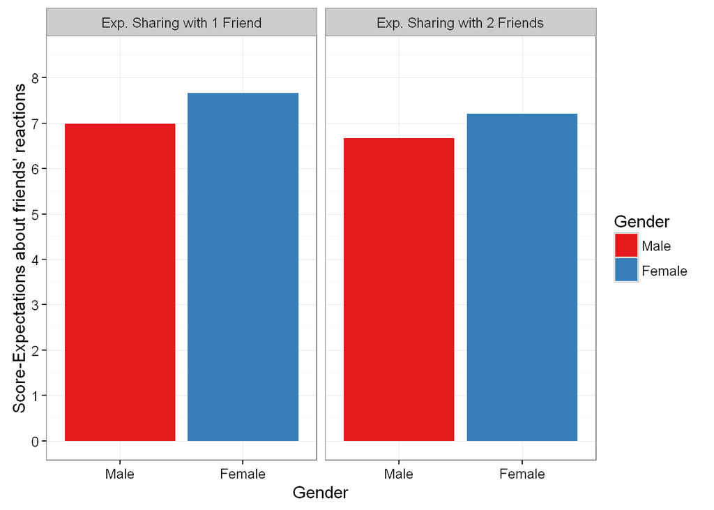

```r
gdata$variable <- factor(gdata$variable,
                     labels = c("Exp. Sharing with 1 Friend",
                                "Exp. Sharing with 2 Friends"))
names(gdata)[1]<-"Gender"

ggplot(gdata, aes(x=Gender, y=value, fill=Gender) )+
        geom_bar(stat = "summary", fun.y = "mean",position="dodge")+
        facet_grid(. ~ variable)+
        scale_fill_brewer(palette="Set1")+
        theme_bw()+
        coord_cartesian(ylim=c(0, 8.5))+
        scale_y_continuous(limits =c(0,9), breaks=seq(0,9, 1))+
        labs(x="Gender",
             y="Score-Expectations about friends' reactions")
```

# Income and schemes’ preferences (Section 3.3.9)

```
## $vd_0f
##
##  Kruskal-Wallis rank sum test
##
## data:  x by final_df[, 26]
## Kruskal-Wallis chi-squared = 10.322, df = 4, p-value = 0.03534
##
##
## $vd_1f
##
##  Kruskal-Wallis rank sum test
##
## data:  x by final_df[, 26]
## Kruskal-Wallis chi-squared = 0.54003, df = 4, p-value = 0.9695
##
##
## $vd_2f
##
##  Kruskal-Wallis rank sum test
##
## data:  x by final_df[, 26]
## Kruskal-Wallis chi-squared = 6.8378, df = 4, p-value = 0.1447
```

### FIGURE 26: Income categories and schemes’ average rankings.

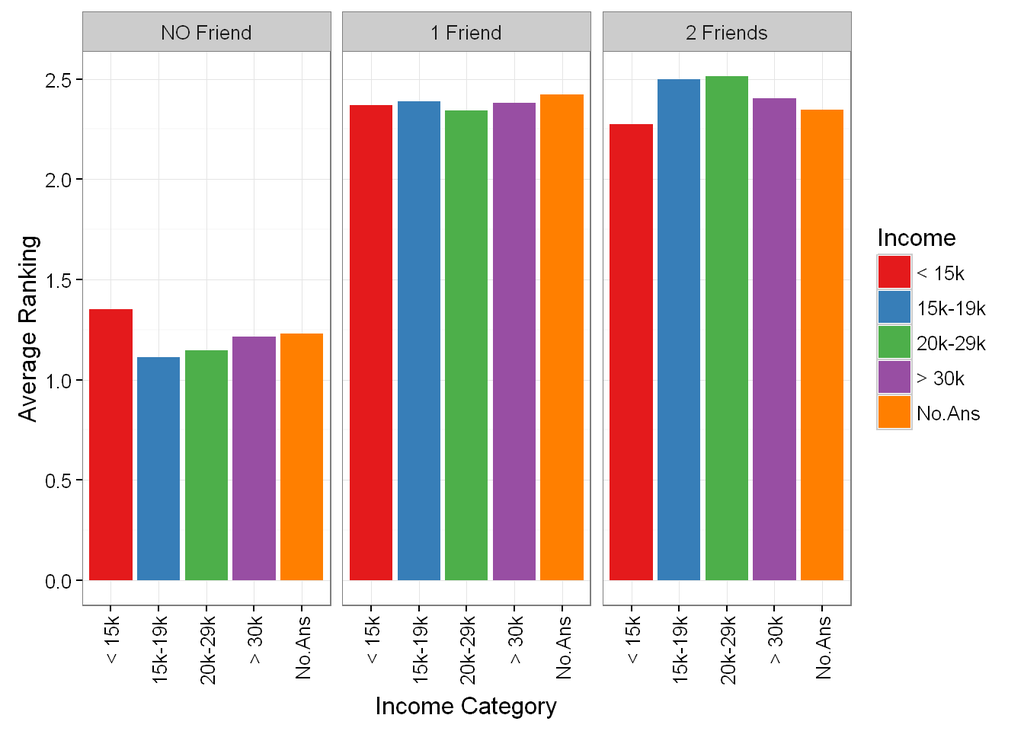

```r
data<-melt(final_df, measure.var= c("vd_0f","vd_1f", "vd_2f"),
         id.var = c("income"))

avg_rank<-data %>% group_by(variable,income) %>%
        summarise(rank=mean(value))

avg_rank$variable <- factor(avg_rank$variable,
                     labels = c("NO Friend", "1 Friend", "2 Friends"))
names(avg_rank)[2]<-"Income"

ggplot(avg_rank, aes(x=Income, y=rank, fill=Income) )+
        geom_bar(stat="identity",position="dodge")+
        facet_grid(~ variable)+
        scale_fill_brewer(palette="Set1")+
        theme_bw()+
        theme(axis.text.x=element_text(angle=90,hjust=1,vjust=0.5))+
        labs(x="Income Category", y="Average Ranking")
```

### FIGURE 27: Income categories and expectations about friends’ reactions.

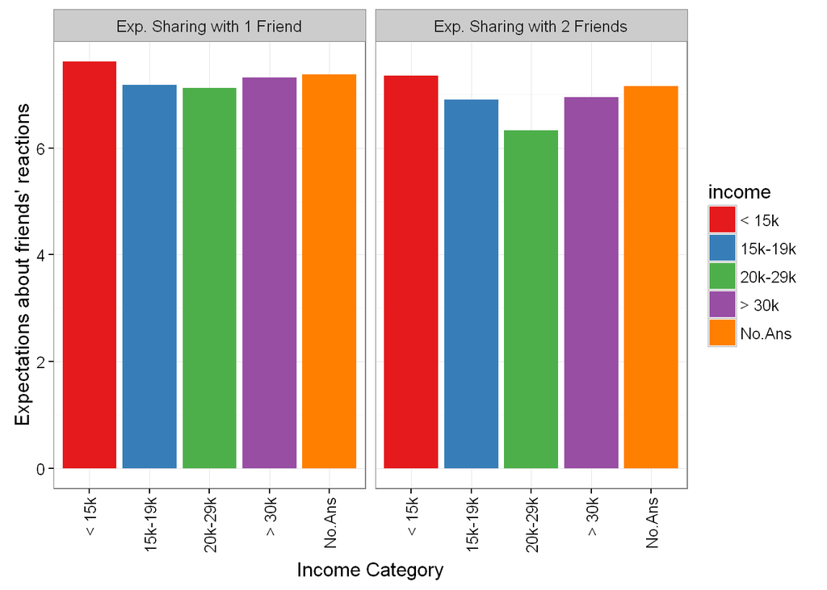

```r
data<-melt(final_df, measure.var= c("tot_exp1", "tot_exp2"),
         id.var = c("income"))


data$variable <- factor(data$variable,
                     labels = c("Exp. Sharing with 1 Friend",
                                "Exp. Sharing with 2 Friends"))
names(avg_rank)[2]<-"Income"

ggplot(data, aes(x=income, y=value, fill=income) )+
        geom_bar(stat = "summary", fun.y = "mean",position="dodge")+
        facet_grid(~ variable)+
        scale_fill_brewer(palette="Set1")+
        theme_bw()+
        theme(axis.text.x=element_text(angle=90,hjust=1,vjust=0.5))+
        #scale_y_continuous(limits =c(0,6), breaks=seq(0,6, 1))+
        labs(x="Income Category", y="Expectations about friends' reactions")
```

### Correlations

```r
data<- final_df %>% select(vd_0f,vd_1f,vd_2f,tot_exp1,tot_exp2,income)                 %>% filter(income!="No.Ans") %>%
                melt(measure.var= c("vd_0f","vd_1f","vd_2f"),
                id.var = c("income","tot_exp1","tot_exp2")) %>%
                filter(value==1) %>%
                melt(measure.var= c("tot_exp1","tot_exp2"),
                id.var = c("income", "variable"))

names(data) <- c("income", "scheme", "exp.cat", "exp.value")
data$income <- as.numeric(data$income)

# Calculate correlation for each group

## Corralatuions value
ddply(data, c("exp.cat","scheme"), summarise, cor = round(cor(income, exp.value, method="spearman"), 4))
```

```
##    exp.cat scheme     cor
## 1 tot_exp1  vd_0f -0.1488
## 2 tot_exp1  vd_1f  0.3831
## 3 tot_exp1  vd_2f  0.0811
## 4 tot_exp2  vd_0f -0.1621
## 5 tot_exp2  vd_1f  0.2068
## 6 tot_exp2  vd_2f  0.0138
```

```r
## p  value
ddply(data, c("exp.cat","scheme"), summarise, p = round(cor.test(income, exp.value, method="spearman")$p.value,4))
```

```
##    exp.cat scheme      p
## 1 tot_exp1  vd_0f 0.0108
## 2 tot_exp1  vd_1f 0.0442
## 3 tot_exp1  vd_2f 0.6817
## 4 tot_exp2  vd_0f 0.0054
## 5 tot_exp2  vd_1f 0.2910
## 6 tot_exp2  vd_2f 0.9446
```

# ADDITIONAL ANALYSIS

## ALPHA FNE and Expectations scales.

```r
library("psych")

## Expectations about friends reactons
f1<-final_df %>% select(exp_x1_K, exp_x1_T, exp_x1_S.R, exp_x1_G)
alpha(as.data.frame(f1))
```

```
##
## Reliability analysis
## Call: alpha(x = as.data.frame(f1))
##
##   raw_alpha std.alpha G6(smc) average_r S/N    ase mean  sd
##       0.95      0.95    0.94      0.83  20 0.0041  7.4 1.7
##
##  lower alpha upper     95% confidence boundaries
## 0.94 0.95 0.96
##
##  Reliability if an item is dropped:
##            raw_alpha std.alpha G6(smc) average_r S/N alpha se
## exp_x1_K        0.92      0.93    0.90      0.81  12   0.0068
## exp_x1_T        0.93      0.94    0.91      0.83  15   0.0057
## exp_x1_S.R      0.95      0.95    0.93      0.86  19   0.0043
## exp_x1_G        0.93      0.93    0.91      0.82  14   0.0060
##
##  Item statistics
##              n raw.r std.r r.cor r.drop mean  sd
## exp_x1_K   401  0.95  0.96  0.94   0.92  7.4 1.7
## exp_x1_T   401  0.93  0.93  0.91   0.88  7.4 1.8
## exp_x1_S.R 401  0.91  0.91  0.86   0.84  7.3 1.9
## exp_x1_G   401  0.94  0.94  0.92   0.89  7.4 1.7
##
## Non missing response frequency for each item
##               1    2    3    4    5    6    7    8    9 miss
## exp_x1_K   0.01 0.00 0.00 0.02 0.13 0.12 0.18 0.14 0.38    0
## exp_x1_T   0.01 0.00 0.01 0.02 0.12 0.09 0.18 0.15 0.40    0
## exp_x1_S.R 0.03 0.01 0.00 0.02 0.12 0.08 0.18 0.17 0.37    0
## exp_x1_G   0.01 0.00 0.00 0.02 0.13 0.12 0.16 0.17 0.38    0
```

```r
f2<-final_df %>% select(exp_x2_K, exp_x2_T, exp_x2_S.R, exp_x2_G)
alpha(as.data.frame(f2))
```

```
##
## Reliability analysis
## Call: alpha(x = as.data.frame(f2))
##
##   raw_alpha std.alpha G6(smc) average_r S/N    ase mean  sd
##       0.94      0.94    0.93      0.81  17 0.0047    7 1.7
##
##  lower alpha upper     95% confidence boundaries
## 0.93 0.94 0.95
##
##  Reliability if an item is dropped:
##            raw_alpha std.alpha G6(smc) average_r S/N alpha se
## exp_x2_K        0.92      0.92    0.88      0.79  11   0.0073
## exp_x2_T        0.92      0.92    0.89      0.80  12   0.0069
## exp_x2_S.R      0.94      0.95    0.92      0.85  17   0.0048
## exp_x2_G        0.92      0.92    0.89      0.80  12   0.0068
##
##  Item statistics
##              n raw.r std.r r.cor r.drop mean  sd
## exp_x2_K   401  0.94  0.94  0.93   0.90  7.0 1.7
## exp_x2_T   401  0.93  0.93  0.91   0.88  7.1 1.8
## exp_x2_S.R 401  0.90  0.89  0.83   0.81  6.9 2.0
## exp_x2_G   401  0.93  0.93  0.91   0.88  6.8 1.8
##
## Non missing response frequency for each item
##               1    2    3    4    5    6    7    8    9 miss
## exp_x2_K   0.01 0.00 0.02 0.02 0.16 0.16 0.20 0.13 0.30    0
## exp_x2_T   0.01 0.00 0.02 0.02 0.15 0.13 0.20 0.13 0.32    0
## exp_x2_S.R 0.03 0.01 0.01 0.02 0.15 0.15 0.19 0.14 0.30    0
## exp_x2_G   0.01 0.01 0.01 0.03 0.20 0.18 0.17 0.12 0.26    0
```

```r
## Fears of Negative evaluations scale.
fne<- final_df %>%
                select(neg.ev_1,neg.ev_2.R,neg.ev_3,
                neg.ev_4.R,neg.ev_5,neg.ev_6,neg.ev_7.R,
                neg.ev_8,neg.ev_9,neg.ev_10.R,neg.ev_11, neg.ev_12)
alpha(as.data.frame(fne))
```

```
##
## Reliability analysis
## Call: alpha(x = as.data.frame(fne))
##
##   raw_alpha std.alpha G6(smc) average_r S/N    ase mean   sd
##        0.9       0.9    0.93      0.43 9.1 0.0075  3.3 0.81
##
##  lower alpha upper     95% confidence boundaries
## 0.89 0.9 0.91
##
##  Reliability if an item is dropped:
##             raw_alpha std.alpha G6(smc) average_r  S/N alpha se
## neg.ev_1         0.89      0.89    0.92      0.42  8.0   0.0086
## neg.ev_2.R       0.91      0.91    0.93      0.48 10.0   0.0070
## neg.ev_3         0.89      0.89    0.92      0.42  7.9   0.0086
## neg.ev_4.R       0.91      0.91    0.93      0.48 10.0   0.0070
## neg.ev_5         0.88      0.88    0.92      0.41  7.7   0.0088
## neg.ev_6         0.88      0.89    0.92      0.41  7.7   0.0088
## neg.ev_7.R       0.90      0.90    0.92      0.45  8.9   0.0075
## neg.ev_8         0.89      0.89    0.92      0.42  8.0   0.0086
## neg.ev_9         0.89      0.89    0.92      0.41  7.8   0.0087
## neg.ev_10.R      0.90      0.90    0.93      0.45  9.0   0.0075
## neg.ev_11        0.89      0.89    0.92      0.42  7.8   0.0088
## neg.ev_12        0.89      0.89    0.92      0.42  8.0   0.0086
##
##  Item statistics
##               n raw.r std.r r.cor r.drop mean  sd
## neg.ev_1    401  0.77  0.77  0.74   0.71  3.7 1.2
## neg.ev_2.R  401  0.41  0.40  0.34   0.30  2.3 1.1
## neg.ev_3    401  0.78  0.78  0.76   0.72  3.8 1.2
## neg.ev_4.R  401  0.41  0.40  0.34   0.30  2.5 1.2
## neg.ev_5    401  0.83  0.83  0.83   0.79  3.9 1.1
## neg.ev_6    401  0.81  0.81  0.81   0.76  3.9 1.1
## neg.ev_7.R  401  0.60  0.59  0.56   0.51  2.6 1.3
## neg.ev_8    401  0.76  0.77  0.76   0.71  3.8 1.1
## neg.ev_9    401  0.80  0.81  0.80   0.76  3.7 1.1
## neg.ev_10.R 401  0.58  0.57  0.53   0.48  2.4 1.2
## neg.ev_11   401  0.80  0.80  0.78   0.74  3.6 1.3
## neg.ev_12   401  0.76  0.76  0.75   0.70  3.6 1.2
##
## Non missing response frequency for each item
##                1    2    3    4    5 miss
## neg.ev_1    0.05 0.09 0.26 0.26 0.33    0
## neg.ev_2.R  0.29 0.28 0.26 0.14 0.03    0
## neg.ev_3    0.03 0.12 0.21 0.25 0.39    0
## neg.ev_4.R  0.23 0.27 0.30 0.14 0.06    0
## neg.ev_5    0.03 0.08 0.21 0.30 0.37    0
## neg.ev_6    0.04 0.09 0.21 0.31 0.36    0
## neg.ev_7.R  0.26 0.27 0.22 0.16 0.10    0
## neg.ev_8    0.04 0.08 0.23 0.31 0.34    0
## neg.ev_9    0.03 0.13 0.25 0.31 0.28    0
## neg.ev_10.R 0.26 0.31 0.25 0.12 0.07    0
## neg.ev_11   0.08 0.15 0.20 0.23 0.33    0
## neg.ev_12   0.06 0.12 0.27 0.25 0.29    0
```

## Explorations not included in Thesis

### Correlations Matrix

#### - Pearson

```r
rxy<- select(final_df, tot_exp1,tot_exp2,exp_all, tot_neg_eval,
           vd_0f, vd_2f, vd_1f, gender, income, age, employ)

rxy[1:ncol(rxy)] <- lapply(rxy[1:ncol(rxy)], function(x) as.numeric(x))

rxy<-as.matrix(rxy)
rcorr(rxy, type="pearson")
```

```
##              tot_exp1 tot_exp2 exp_all tot_neg_eval vd_0f vd_2f vd_1f
## tot_exp1         1.00     0.80    0.95        -0.02  0.07 -0.04 -0.03
## tot_exp2         0.80     1.00    0.95         0.03  0.11 -0.11  0.00
## exp_all          0.95     0.95    1.00         0.00  0.10 -0.08 -0.01
## tot_neg_eval    -0.02     0.03    0.00         1.00 -0.01 -0.04  0.05
## vd_0f            0.07     0.11    0.10        -0.01  1.00 -0.47 -0.43
## vd_2f           -0.04    -0.11   -0.08        -0.04 -0.47  1.00 -0.59
## vd_1f           -0.03     0.00   -0.01         0.05 -0.43 -0.59  1.00
## gender           0.20     0.16    0.19        -0.27 -0.01  0.02 -0.01
## income          -0.06    -0.07   -0.07         0.07 -0.07  0.05  0.02
## age              0.03     0.06    0.05         0.29 -0.05  0.04  0.00
## employ           0.08     0.05    0.07         0.01 -0.05  0.04  0.00
##              gender income   age employ
## tot_exp1       0.20  -0.06  0.03   0.08
## tot_exp2       0.16  -0.07  0.06   0.05
## exp_all        0.19  -0.07  0.05   0.07
## tot_neg_eval  -0.27   0.07  0.29   0.01
## vd_0f         -0.01  -0.07 -0.05  -0.05
## vd_2f          0.02   0.05  0.04   0.04
## vd_1f         -0.01   0.02  0.00   0.00
## gender         1.00  -0.10 -0.22   0.10
## income        -0.10   1.00 -0.11  -0.27
## age           -0.22  -0.11  1.00   0.44
## employ         0.10  -0.27  0.44   1.00
##
## n= 401
##
##
## P
##              tot_exp1 tot_exp2 exp_all tot_neg_eval vd_0f  vd_2f  vd_1f
## tot_exp1              0.0000   0.0000  0.6457       0.1461 0.4655 0.5618
## tot_exp2     0.0000            0.0000  0.6159       0.0226 0.0347 0.9365
## exp_all      0.0000   0.0000           0.9788       0.0487 0.1328 0.7943
## tot_neg_eval 0.6457   0.6159   0.9788               0.8393 0.3764 0.2749
## vd_0f        0.1461   0.0226   0.0487  0.8393              0.0000 0.0000
## vd_2f        0.4655   0.0347   0.1328  0.3764       0.0000        0.0000
## vd_1f        0.5618   0.9365   0.7943  0.2749       0.0000 0.0000
## gender       0.0000   0.0014   0.0001  0.0000       0.8580 0.7405 0.8605
## income       0.2700   0.1576   0.1842  0.1802       0.1448 0.3329 0.7335
## age          0.5553   0.2125   0.3315  0.0000       0.3211 0.3798 0.9941
## employ       0.1251   0.2783   0.1682  0.9028       0.3595 0.4299 0.9767
##              gender income age    employ
## tot_exp1     0.0000 0.2700 0.5553 0.1251
## tot_exp2     0.0014 0.1576 0.2125 0.2783
## exp_all      0.0001 0.1842 0.3315 0.1682
## tot_neg_eval 0.0000 0.1802 0.0000 0.9028
## vd_0f        0.8580 0.1448 0.3211 0.3595
## vd_2f        0.7405 0.3329 0.3798 0.4299
## vd_1f        0.8605 0.7335 0.9941 0.9767
## gender              0.0494 0.0000 0.0359
## income       0.0494        0.0343 0.0000
## age          0.0000 0.0343        0.0000
## employ       0.0359 0.0000 0.0000
```

#### - Spearman

```r
rxy<- select(final_df, tot_exp1,tot_exp2,exp_all,tot_neg_eval,
            vd_0f, vd_2f, vd_1f, gender, income, age, employ)

rxy[1:ncol(rxy)] <- lapply(rxy[1:ncol(rxy)], function(x) as.numeric(x))

rxy<-as.matrix(rxy)
rcorr(rxy, type="spearman")
```

```
##              tot_exp1 tot_exp2 exp_all tot_neg_eval vd_0f vd_2f vd_1f
## tot_exp1         1.00     0.82    0.94         0.01  0.08 -0.02 -0.04
## tot_exp2         0.82     1.00    0.96         0.06  0.10 -0.11  0.01
## exp_all          0.94     0.96    1.00         0.04  0.09 -0.07 -0.01
## tot_neg_eval     0.01     0.06    0.04         1.00  0.01 -0.03  0.04
## vd_0f            0.08     0.10    0.09         0.01  1.00 -0.34 -0.36
## vd_2f           -0.02    -0.11   -0.07        -0.03 -0.34  1.00 -0.71
## vd_1f           -0.04     0.01   -0.01         0.04 -0.36 -0.71  1.00
## gender           0.19     0.16    0.19        -0.25 -0.02  0.02 -0.02
## income          -0.08    -0.07   -0.07         0.06 -0.09  0.04  0.00
## age              0.03     0.07    0.05         0.29 -0.04  0.03  0.00
## employ           0.07     0.06    0.07         0.02 -0.03  0.03  0.00
##              gender income   age employ
## tot_exp1       0.19  -0.08  0.03   0.07
## tot_exp2       0.16  -0.07  0.07   0.06
## exp_all        0.19  -0.07  0.05   0.07
## tot_neg_eval  -0.25   0.06  0.29   0.02
## vd_0f         -0.02  -0.09 -0.04  -0.03
## vd_2f          0.02   0.04  0.03   0.03
## vd_1f         -0.02   0.00  0.00   0.00
## gender         1.00  -0.10 -0.21   0.14
## income        -0.10   1.00 -0.11  -0.30
## age           -0.21  -0.11  1.00   0.42
## employ         0.14  -0.30  0.42   1.00
##
## n= 401
##
##
## P
##              tot_exp1 tot_exp2 exp_all tot_neg_eval vd_0f  vd_2f  vd_1f
## tot_exp1              0.0000   0.0000  0.7948       0.1052 0.6458 0.4364
## tot_exp2     0.0000            0.0000  0.2364       0.0493 0.0331 0.7646
## exp_all      0.0000   0.0000           0.4274       0.0639 0.1528 0.8670
## tot_neg_eval 0.7948   0.2364   0.4274               0.8499 0.5172 0.3930
## vd_0f        0.1052   0.0493   0.0639  0.8499              0.0000 0.0000
## vd_2f        0.6458   0.0331   0.1528  0.5172       0.0000        0.0000
## vd_1f        0.4364   0.7646   0.8670  0.3930       0.0000 0.0000
## gender       0.0001   0.0011   0.0000  0.0000       0.7588 0.6504 0.7165
## income       0.1168   0.1426   0.1526  0.2485       0.0837 0.3741 0.9242
## age          0.5934   0.1802   0.2799  0.0000       0.4086 0.5206 0.9798
## employ       0.1401   0.2429   0.1522  0.6826       0.5453 0.4993 0.9904
##              gender income age    employ
## tot_exp1     0.0001 0.1168 0.5934 0.1401
## tot_exp2     0.0011 0.1426 0.1802 0.2429
## exp_all      0.0000 0.1526 0.2799 0.1522
## tot_neg_eval 0.0000 0.2485 0.0000 0.6826
## vd_0f        0.7588 0.0837 0.4086 0.5453
## vd_2f        0.6504 0.3741 0.5206 0.4993
## vd_1f        0.7165 0.9242 0.9798 0.9904
## gender              0.0529 0.0000 0.0058
## income       0.0529        0.0325 0.0000
## age          0.0000 0.0325        0.0000
## employ       0.0058 0.0000 0.0000
```

### Employment / Scheme preferences

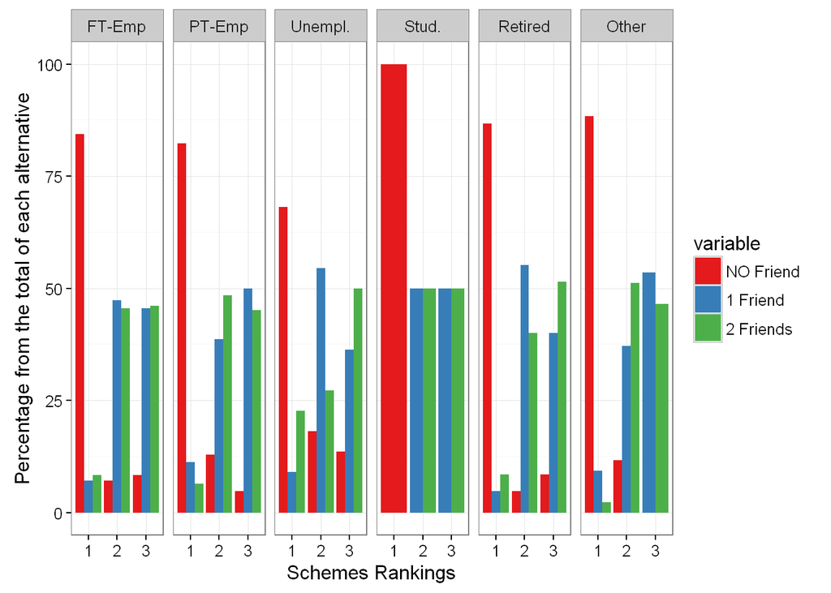

```r
data<-melt(final_df, measure.var= c("vd_0f","vd_1f", "vd_2f"),
         id.var = c("employ"))

fr1 <- data %>%
        group_by(variable,employ,value) %>%
        summarise(n=n())
fr2 <- fr1 %>%
        group_by(employ, variable) %>%
        summarise(n=sum(n))
pct <- left_join(fr1, fr2, by = c("employ"="employ",
                                  "variable"="variable")) %>%
        mutate(perc=100*n.x/(n.y))


pct$variable <- factor(pct$variable,
                labels = c("NO Friend", "1 Friend", "2 Friends"))
pct$value <- factor(pct$value)

names(pct)[2]<-"employ"

ggplot(pct, aes(x=value, y=perc, fill=variable) )+
        geom_bar(stat="identity",position="dodge")+
        facet_grid(~ employ)+
        scale_fill_brewer(palette="Set1")+
        theme_bw()+
        labs(x="Schemes Rankings", y="Percentage from the total of each alternative")
```

### Income / Scheme preferences

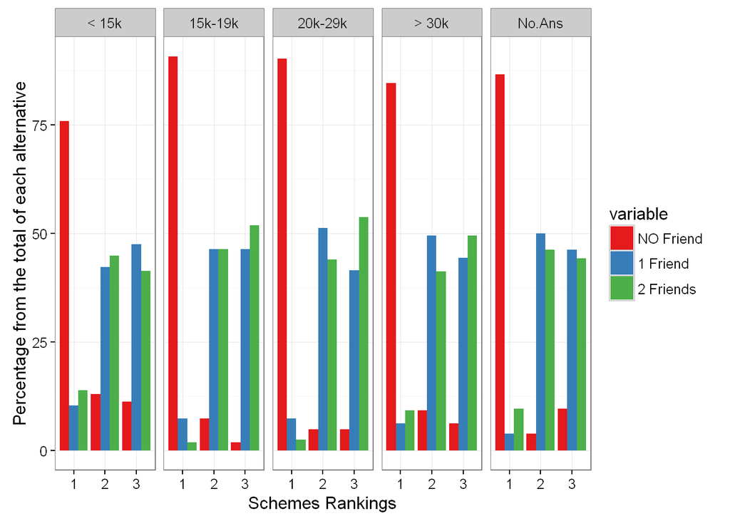

```r
data<-melt(final_df, measure.var= c("vd_0f","vd_1f", "vd_2f"),
         id.var = c("income"))


fr1 <- data %>%
        group_by(variable,income,value) %>%
        summarise(n=n())
fr2 <- fr1 %>%
        group_by(income, variable) %>%
        summarise(n=sum(n))
pct <- left_join(fr1, fr2, by = c("income"="income",
                                  "variable"="variable")) %>%
        mutate(perc=100*n.x/(n.y))

pct$variable <- factor(pct$variable,
                labels = c("NO Friend", "1 Friend", "2 Friends"))
pct$value <- factor(pct$value)

names(pct)[2]<-"income"

ggplot(pct, aes(x=value, y=perc, fill=variable) )+
        geom_bar(stat="identity",position="dodge")+
        facet_grid(~ income)+
        scale_fill_brewer(palette="Set1")+
        theme_bw()+
        labs(x="Schemes Rankings", y="Percentage from the total of each alternative")
```

### Income / Scheme preferences (AVERAGE RANKING)

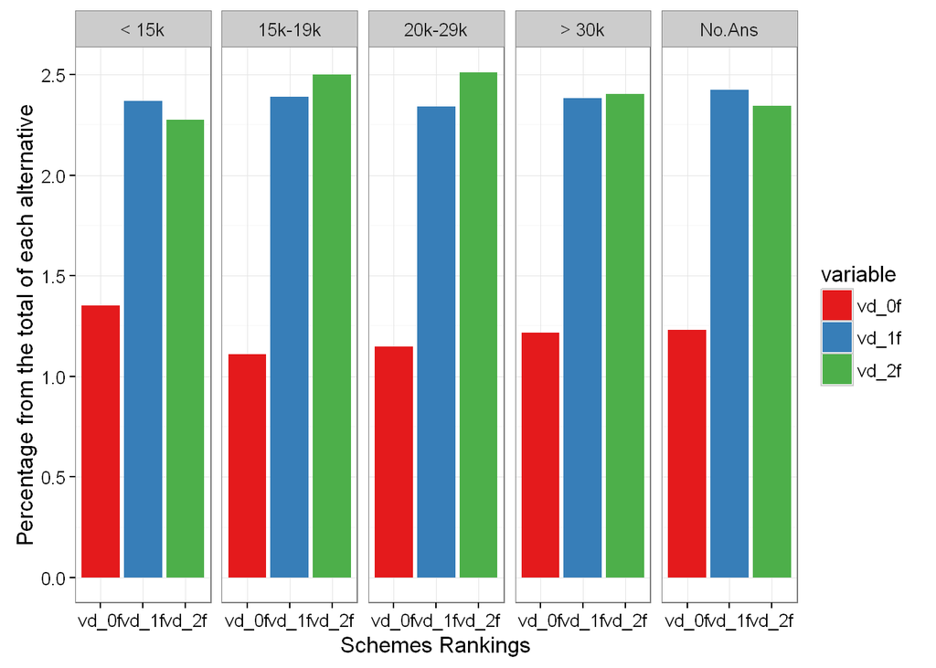

```r
data<-melt(final_df, measure.var= c("vd_0f","vd_1f", "vd_2f"),
         id.var = c("income"))

avg_rank<-data %>% group_by(variable,income) %>%
        summarise(rank=mean(value))


ggplot(avg_rank, aes(x=variable, y=rank, fill=variable) )+
        geom_bar(stat="identity",position="dodge")+
        facet_grid(~ income)+
        scale_fill_brewer(palette="Set1")+
        theme_bw()+
        labs(x="Schemes Rankings", y="Percentage from the total of each alternative")
```